### Deal with NAs

##### Put `NA` for certain values in column A based on the values in column B (e.g., if `Time` equals 2, put `NA` to `weight`) (package: `dplyr`)

```r
new.dat = ChickWeight %>% mutate(weight = replace(weight, which(Time==2), NA))
head(new.dat)
```

```
## Grouped Data: weight ~ Time | Chick
##   weight Time Chick Diet
## 1     42    0     1    1
## 2     NA    2     1    1
## 3     59    4     1    1
## 4     64    6     1    1
## 5     76    8     1    1
## 6     93   10     1    1
```

##### Put `NA` for values that deviate more than 2.5 SDs from the group mean (e.g, `NA` if `weight` deviates more than 2.5 SDs from the mean of the `Diet` group) (package: `dplyr`)

```r
new.dat = ChickWeight %>% group_by(Diet) %>% mutate(zWeight = scale(weight), weight = replace(weight, which(!between(zWeight, -2.5, 2.5)), NA))

new.dat %>% filter(is.na(weight)) # check rows with `NA`
```

```
## # A tibble: 13 × 5
## # Groups:   Diet [4]
##    weight  Time Chick Diet  zWeight[,1]
##     <dbl> <dbl> <ord> <fct>       <dbl>
##  1     NA    18 7     1            2.60
##  2     NA    20 7     1            3.27
##  3     NA    21 7     1            3.57
##  4     NA    18 14    1            2.57
##  5     NA    20 14    1            2.76
##  6     NA    21 14    1            2.88
##  7     NA    18 21    2            2.57
##  8     NA    20 21    2            2.73
##  9     NA    21 21    2            2.91
## 10     NA    21 29    2            2.60
## 11     NA    20 35    3            2.52
## 12     NA    21 35    3            2.66
## 13     NA    21 48    4            2.71
```

##### Compute the proportion of NA

```r
sum(is.na(new.dat$weight))/length(new.dat$weight)
```

```
## [1] 0.02249135
```

##### Drop rows containing NA (package: `tidyr`)

```r
dat.na.dropped = new.dat %>% drop_na(weight) # drop row if the column weight contains NA
dat.na.dropped = new.dat %>% drop_na() # drop row if any of the column contains NA
```

##### Replace NA with 0 across multiple columns

```r
dat.na.replaced = new.dat %>% mutate_at(vars(weight,Time), ~replace_na(., 0))

summary(dat.na.replaced) # to check
```

```
##      weight         Time           Chick     Diet        zWeight.V1
##  Min.   :  0   Min.   : 0.00   13     : 12   1:220   Min.   :-1.398584
##  1st Qu.: 61   1st Qu.: 4.00   9      : 12   2:120   1st Qu.:-0.818295
##  Median :100   Median :10.00   20     : 12   3:120   Median :-0.213647
##  Mean   :115   Mean   :10.72   10     : 12   4:118   Mean   : 0.000000
##  3rd Qu.:157   3rd Qu.:16.00   17     : 12           3rd Qu.: 0.622965
##  Max.   :341   Max.   :21.00   19     : 12           Max.   : 3.571600
##                                (Other):506
```

### Plot

##### Histogram (package: `ggplot2`)

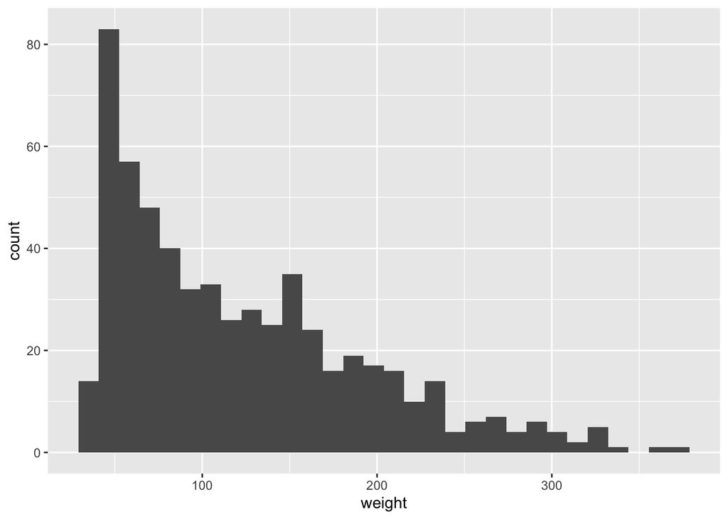

```r
ggplot(ChickWeight, aes(x=weight)) + geom_histogram()
```

##### Correlation plot (package: `ggplot2`)

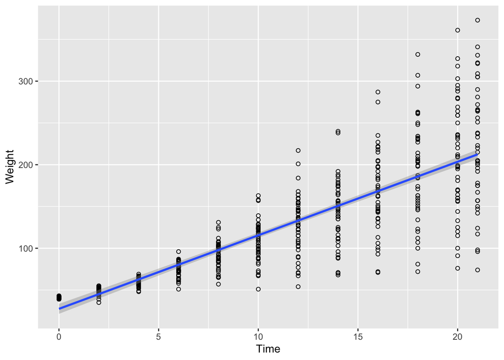

```r
ggplot(ChickWeight, aes(x=Time, y=weight)) +
  geom_point(shape=1) +
  geom_smooth(method=lm) +
  xlab('Time') +
  ylab('Weight')
```

Group by `Diet`

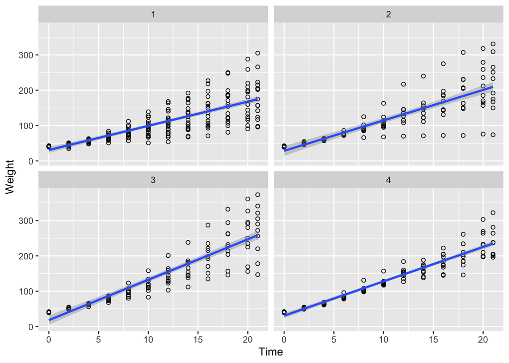

```r
ggplot(ChickWeight, aes(x=Time, y=weight)) +
  geom_point(shape=1) +
  geom_smooth(method=lm) +
  xlab('Time') +
  ylab('Weight') +
  facet_wrap(vars(Diet), ncol=2)
```

##### Bar graph with error bars (with 95% CI) (package: `ggplot2`)

First, create a summarised data frame for plotting (package: `Rmisc`)

```r
plot.dat = summarySE(ChickWeight, measurevar="weight", groupvars=c("Diet"),na.rm=T)
plot.dat # check data
```

```
##   Diet   N   weight       sd       se        ci
## 1    1 220 102.6455 56.65655 3.819784  7.528242
## 2    2 120 122.6167 71.60749 6.536840 12.943596
## 3    3 120 142.9500 86.54176 7.900146 15.643078
## 4    4 118 135.2627 68.82871 6.336197 12.548506
```

Plot

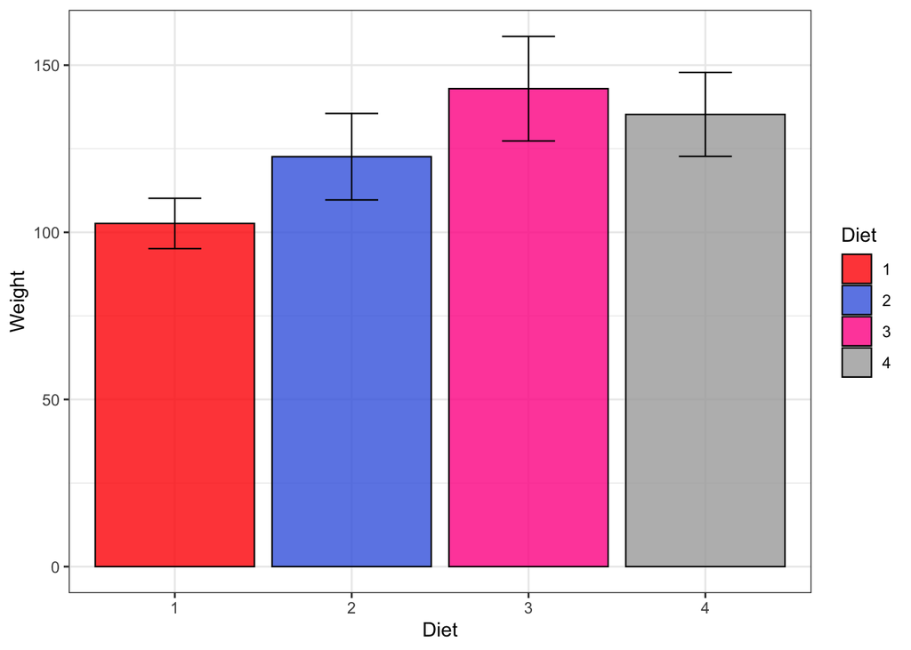

```r
ggplot(plot.dat, aes(x=Diet, y=weight, fill=Diet)) +
  theme_bw() + # optional theme
geom_bar(position=position_dodge(),stat="identity",colour="black",size=.4,alpha=.8) +
  geom_errorbar(aes(ymin=weight-ci, ymax=weight+ci),size=.4,width=.3) +
  scale_fill_manual('Diet',values=c('red','royalblue','deeppink','darkgrey')) +
  xlab("Diet") +
  ylab("Weight")
```

### Special characters

##### Convert Japanese full-width characters (Zenkaku) into half-width (Hankaku) (package: `stringi`)

```r
Age = c('21','18','１９','３１','29')
stri_trans_nfkc(Age)
```

```
## [1] "21" "18" "19" "31" "29"
```

##### Remove/Change characters (package: `stringr`)

```r
example = c('high (not sure)','high','Low','High','low?','medium','medium/low')
str_replace_all(example,c('\\/.*'='', # remove all characters after '/'
                          '\\(.*'='', # remove all characters after '('
                          '[[:punct:]]'='')) # remove all special characters
```

```
## [1] "high "  "high"   "Low"    "High"   "low"    "medium" "medium"
```

```r
str_to_lower(example) # convert string to lowercase
```

```
## [1] "high (not sure)" "high"            "low"             "high"
## [5] "low?"            "medium"          "medium/low"
```

```r
str_to_upper(example) # convert string to uppercase
```

```
## [1] "HIGH (NOT SURE)" "HIGH"            "LOW"             "HIGH"
## [5] "LOW?"            "MEDIUM"          "MEDIUM/LOW"
```

**Note:** The above codes can be embedded in `dplyr` chain

```r
dat = dat %>% mutate(Age=stri_trans_nfkc(Age), Values=str_replace_all(Values,'[[:punct:]]'=''))
```